# Смешанные линейные модели (случайный интерсепт и случайный угол наклона)

Линейные модели…

Вадим Хайтов, Валентина Домашкина, Анастасия Лянгузова, Наталья Арбузова, Юта Тамберг, Марина Варфоломеева

Кафедра Зоологии беспозвоночных, СПбГУ

## Вы узнаете

- Что такое смешанные модели и когда они применяются
- Что такое фиксированные и случайные факторы

### Вы сможете

- Рассказать чем фиксированные факторы отличаются от случайных
- Привести примеры факторов, которые могут быть фиксированными или случайными в зависимости от задачи исследования
- Рассказать, что оценивает коэффициент внутриклассовой корреляции и вычислить его для случая с одним случайным фактором
- Подобрать смешанную линейную модель со случайным отрезком и случайным углом наклона в R при помощи методов максимального правдоподобия

## “Многоуровневые” данные

## Независимость наблюдений

Обычные линейные модели предполагают, что наблюдения должны быть независимы друг от друга.

Но так происходит совсем не всегда.

### Многоуровневые (multilevel), сгруппированные (clustered) данные

Иногда наблюдения бывают сходны по каким-то признакам:

- измерения в разные периоды времени
  - измерения, сделанные в химической лаборатории в разные дни
- измерения в разных участках пространства
  - урожай на участках одного поля
  - детали, произведенные на одном из нескольких аналогичных станков
- повторные измерения на одних и тех же субъектах
  - измерения до и после какого-то воздействия
- измерения на разных субъектах, которые сами объединены в группы
  - ученики в классах, классы в школах, школы в районах, районы в городах и т.п.

## Внутригрупповые корреляции

Детали, произведенные на одном станке будут более похожи, чем детали, сделанные на разных.

Аналогично, у учеников из одного класса будет более похожий уровень подготовки к какому-нибудь предмету, чем у учеников из разных классов.

Таким образом, можно сказать, что есть корреляции значений внутри групп.

### Последствия для анализа

Игнорировать такую группирующую структуру данных нельзя – можно ошибиться с выводами.

Моделировать группирующие факторы обычными методами тоже нельзя – придется подбирать очень много параметров.

Решение – **случайные факторы**.

Сейчас давайте на примере убедимся в том, что без случайных факторов бывает сложно справиться с анализом.

## Недосып и время реакции

## Недосып и время реакции

В ночь перед нулевым днем всем испытуемым давали поспать нормальное время, а в следующие 9 ночей — только по 3 часа. Каждый день измеряли время реакции в серии тестов. (Данные Belenky et al., 2003)

Как время реакции людей зависит от бессонницы?

- `Reaction` — среднее время реакции в серии тестов в день наблюдения, мс
- `Days` — число дней депривации сна
- `Subject` — номер испытуемого

```r
library(lme4)
data(sleepstudy)

sl <- sleepstudy
str(sl)
```

```
'data.frame':   180 obs. of  3 variables:
 $ Reaction: num  250 259 251 321 357 ...
 $ Days    : num  0 1 2 3 4 5 6 7 8 9 ...
 $ Subject : Factor w/ 18 levels "308","309","310",..: 1 1 1 1 1 1 1 1 1 1 ...
```

## Знакомимся с данными

```r
# Есть ли пропущенные значения?
colSums(is.na(sl))
```

```
Reaction     Days  Subject
       0        0        0
```

```r
# Сколько субъектов?
length(unique(sl$Subject))
```

```
[1] 18
```

```r
# Сколько наблюдений для каждого субъекта?
table(sl$Subject)
```

```
308 309 310 330 331 332 333 334 335 337 349 350 351 352 369 370 371 372
 10  10  10  10  10  10  10  10  10  10  10  10  10  10  10  10  10  10
```

## Есть ли выбросы?

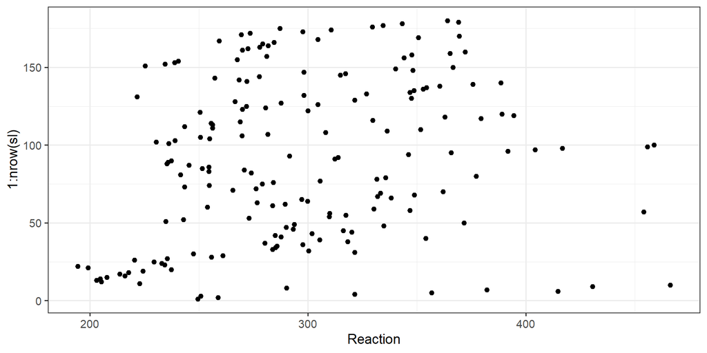

```r
library(ggplot2)
theme_set(theme_bw(base_size = 14))

ggplot(sl, aes(x = Reaction, y = 1:nrow(sl))) +
  geom_point()
```

Мы пока еще не учли информацию о субъектах…

## Как меняется время реакции разных людей?

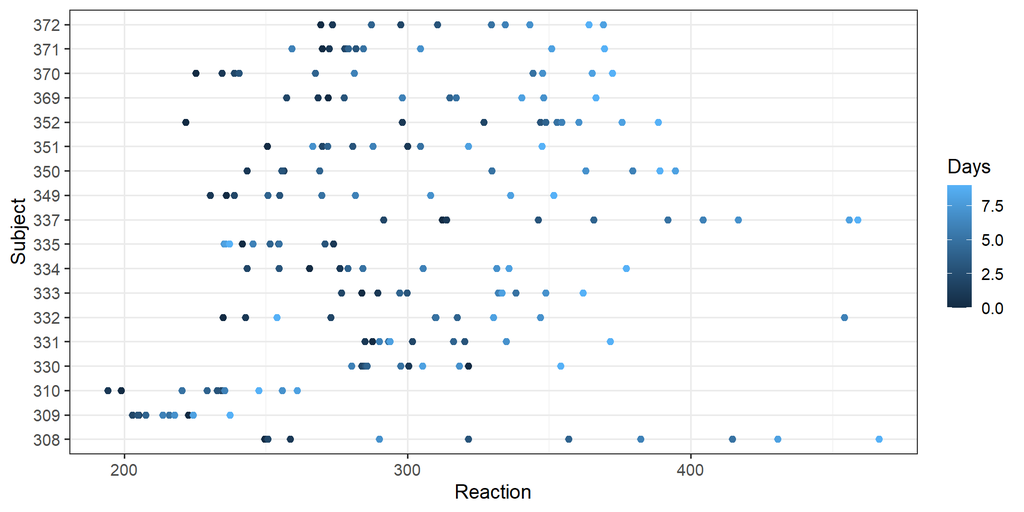

```r
ggplot(sl, aes(x = Reaction, y = Subject, colour = Days)) +
  geom_point()
```

- У разных людей разное время реакции.
- Межиндивидуальную изменчивость нельзя игнорировать.

## Что делать с разными субъектами?

### Good Bad and Ugly

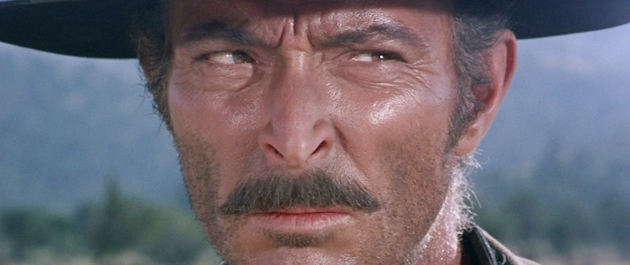

The Bad — игнорируем структуру данных, подбираем модель с единственным фиксированным фактором `Days`. (Не учитываем группирующий фактор `Subject`). Неправильный вариант.

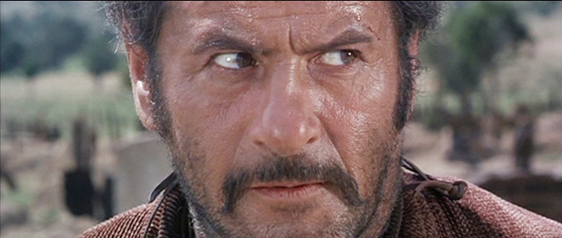

The Ugly — подбираем модель с двумя фиксированными факторами: `Days` и `Subject`. (Группирующий фактор `Subject` опишет межиндивидуальную изменчивость как обычный фиксированный фактор).

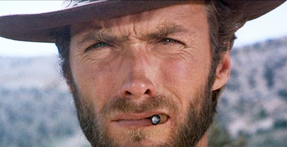

The Good — подбираем смешанную модель, в которой есть фиксированный фактор `Days` и случайный фактор `Subject`, который опишет межиндивидуальную изменчивость.

## Плохое решение: не учитываем группирующий фактор

$$Reaction_{i} = \beta_0 + \beta_1 Days_{i} + \varepsilon_{i}$$

$$\varepsilon_i \sim N(0, \sigma)$$

В матричном виде это можно записать так:

$$\begin{pmatrix} Reaction _{1} \\ Reaction _{2} \\ \vdots \\ Reaction _{180} \end{pmatrix} =
\begin{pmatrix} 1 & Days _{1} \\ 1 & Days _{2} \\ \vdots \\ 1 & Days _{180}\end{pmatrix}
\begin{pmatrix}\beta _0 \\ \beta _1 \end{pmatrix} +
\begin{pmatrix} \varepsilon _{1} \\ \varepsilon _{2}\\ \vdots \\ \varepsilon _{180} \end{pmatrix}$$

что можно сокращенно записать так:

$$\mathbf{Reaction} = \mathbf{X} \pmb{\beta} + \pmb{\varepsilon}$$

## Плохое решение: не учитываем группирующий фактор

```r
W1 <- glm(Reaction ~ Days, data = sl)
summary(W1)
```

```
Call:
glm(formula = Reaction ~ Days, data = sl)

Coefficients:
            Estimate Std. Error t value Pr(>|t|)
(Intercept)  251.405      6.610  38.033  < 2e-16 ***
Days          10.467      1.238   8.454 9.89e-15 ***
---
Signif. codes:  0 '***' 0.001 '**' 0.01 '*' 0.05 '.' 0.1 ' ' 1

(Dispersion parameter for gaussian family taken to be 2276.694)

    Null deviance: 567954  on 179  degrees of freedom
Residual deviance: 405252  on 178  degrees of freedom
AIC: 1906.3

Number of Fisher Scoring iterations: 2
```

- Объем выборки завышен (180 наблюдений, вместо 18 субъектов). Стандартные ошибки и уровни значимости занижены. **Увеличивается вероятность ошибок I рода**.
- Нарушено условие независимости наблюдений.

## Плохое решение: не учитываем группирующий фактор

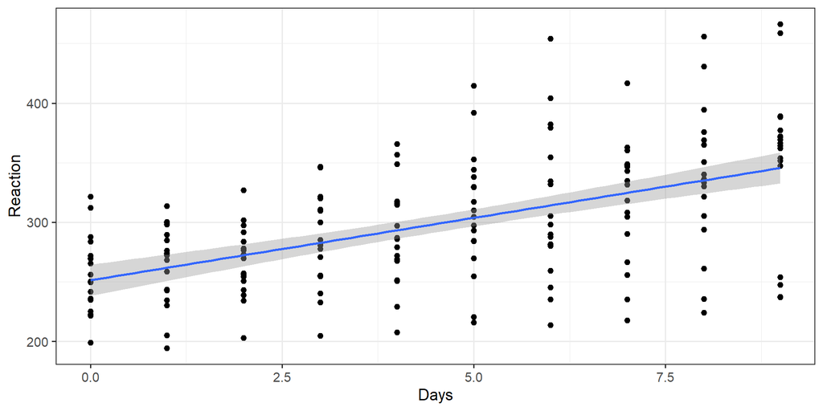

```r
ggplot(sl, aes(x = Days, y = Reaction)) +
  geom_point() +
  geom_smooth(se = TRUE, method = "lm", size = 1)
```

- Доверительная зона регрессии “заужена”.
- Большие остатки, т.к. неучтенная межиндивидуальная изменчивость “ушла” в остаточную.

## Громоздкое решение: группирующий фактор как фиксированный

$$Reaction_{i} = \beta_0 + \beta_1 Days_{i} + \beta_{2}Subj_{2\,i} + ... + \beta_{18}Subj_{18\,i} + \varepsilon_{i}$$

$$\varepsilon_{i} \sim N(0, \sigma)$$

В матричном виде это можно записать так:

$$\begin{pmatrix} Reaction _{1} \\ Reaction _{2} \\ \vdots \\ Reaction _{180} \end{pmatrix} =
\begin{pmatrix} 1 & Days _{1} & Subj_{2\,1} & \cdots & Subj_{18\,1} \\ 1 & Days _{2} & Subj_{2\,2} & \cdots & Subj_{18\,2} \\ \vdots \\ 1 & Days _{180} & Subj_{2\,180} & \cdots & Subj_{18\,180} \end{pmatrix}
\begin{pmatrix} \beta _0 \\ \beta _1 \\ \vdots \\ \beta_{18} \end{pmatrix} +
\begin{pmatrix} \varepsilon _{1} \\ \varepsilon _{2}\\ \vdots \\ \varepsilon _{180} \end{pmatrix}$$

То есть: $\mathbf{Reaction} = \mathbf{X} \pmb{\beta} + \pmb{\varepsilon}$

## Громоздкое решение: группирующий фактор как фиксированный

```r
W2 <- glm(Reaction ~ Days + Subject, data = sl)
coef(W2)
```

```
(Intercept)        Days  Subject309  Subject310
  295.03104    10.46729  -126.90085  -111.13256
 Subject330  Subject331  Subject332  Subject333
  -38.91241   -32.69778   -34.83176   -25.97552
 Subject334  Subject335  Subject337  Subject349
  -46.83178   -92.06379    33.58718   -66.29936
 Subject350  Subject351  Subject352  Subject369
  -28.53115   -52.03608    -4.71229   -36.09919
 Subject370  Subject371  Subject372
  -50.43206   -47.14979   -24.24770
```

Фрагмент `summary(W2)`:

```
Residual standard error: 30.99 on 161 degrees of freedom
Multiple R-squared:  0.7277,    Adjusted R-squared:  0.6973
F-statistic: 23.91 on 18 and 161 DF,  p-value: < 2.2e-16
```

- 20 параметров (18 для `Subject`, один для `Days` и $\sigma$), а наблюдений всего 180.
- Нужно минимум 10–20 наблюдений на каждый параметр (Harrell, 2013) — у нас всего 9.

## Громоздкое решение: что нам делать с этим множеством прямых?

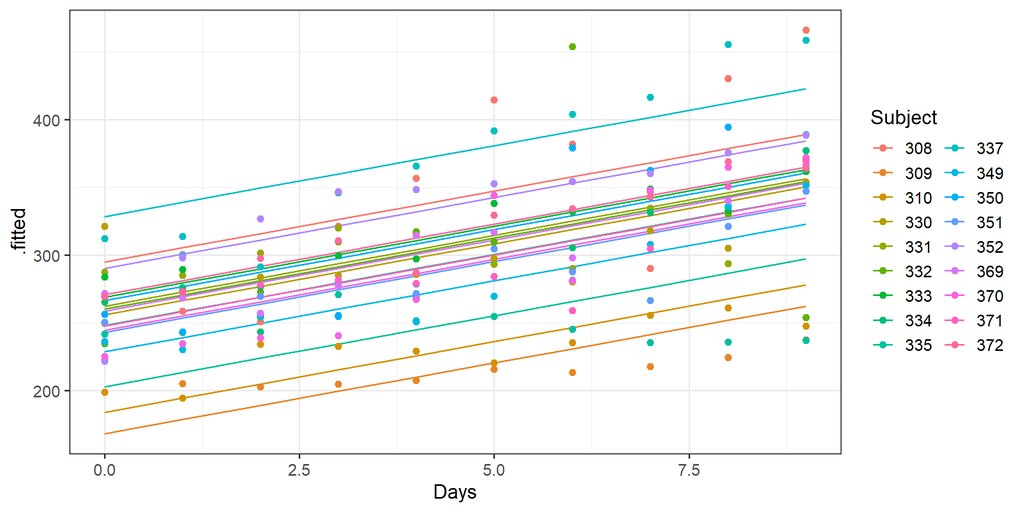

```r
ggplot(fortify(W2), aes(x = Days, colour = Subject)) +
  geom_line(aes(y = .fitted, group = Subject)) +
  geom_point(data = sl, aes(y = Reaction)) +
  guides(colour = guide_legend(ncol = 2))
```

- В модели, где субъект — фиксированный фактор, для каждого субъекта есть “поправка” для значения свободного члена в уравнении регрессии.
- Универсальность модели теряется: предсказания можно сделать только с учетом субъекта.

## Фиксированные и случайные факторы

## Фиксированные факторы

До сих пор мы имели дело только с фиксированными факторами.

Мы моделировали средние значения для уровней фиксированного фактора. Если групп было много, то приходилось моделировать много средних значений.

Поступая так, мы считали, что сравниваемые группы – фиксированные, и нам интересны именно сравнения между ними.

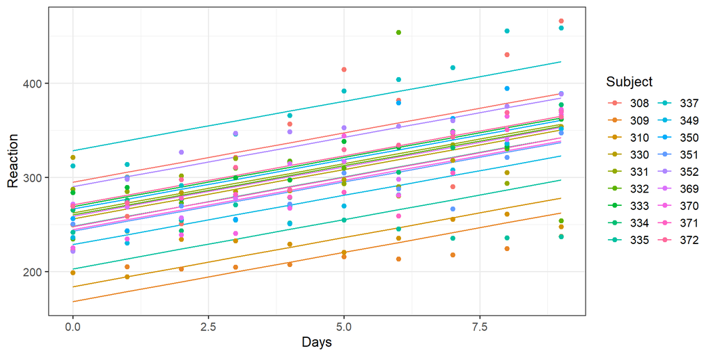

## Можно посмотреть на группирующий фактор иначе!

Когда нам не важны конкретные значения интерсептов для разных уровней фактора, мы можем представить, что эффект фактора (величина “поправки”) — *случайная величина*, и можем оценить дисперсию между уровнями группирующего фактора.

Такие факторы называются **случайными факторами**.

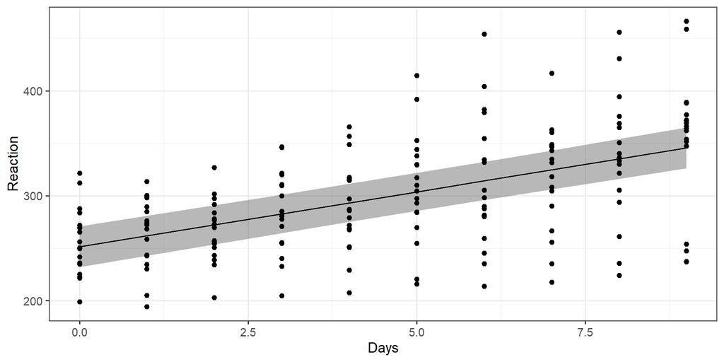

## Случайные факторы

- измерения в разные периоды времени
  - измерения, сделанные в химической лаборатории в разные дни
- измерения в разных участках пространства
  - урожай на участках одного поля
  - детали, произведенные на одном из нескольких аналогичных станков
- повторные измерения на одних и тех же субъектах
  - измерения до и после какого-то воздействия
- измерения на разных субъектах, которые сами объединены в группы
  - ученики в классах, классы в школах, школы в районах, районы в городах и т.п.

### Случайные факторы в моделях

На один и тот же фактор можно посмотреть и как на фиксированный и как на случайный в зависимости от целей исследователя.

Поскольку моделируя случайный фактор мы оцениваем дисперсию между уровнями, то хорошо, если у случайного фактора будет *минимум пять* градаций.

## GLMM со случайным отрезком (Random intercept models)

## GLMM со случайным отрезком

$$Reaction_{ij} = \beta_0 + \beta_1 Days_{ij} + b_{i} + \varepsilon_{ij}$$

- случайный эффект субъекта (случайный отрезок, интерсепт): $b_{i} \sim N(0, \sigma_b)$
- остатки модели: $\varepsilon_{ij} \sim N(0, \sigma)$
- $i$ — субъекты,
- $j$ — дни

В матричном виде это записывается так:

$$\begin{pmatrix} Reaction _{1} \\ Reaction _{2} \\ \vdots \\ Reaction _{180} \end{pmatrix} =
\begin{pmatrix} 1 & Days _{1} \\ 1 & Days _{2} \\ \vdots \\ 1 & Days _{180} \end{pmatrix}
\begin{pmatrix} \beta _0 \\ \beta _1 \end{pmatrix} +
\begin{pmatrix} 1 \\ 1 \\ \vdots \\ 1 \end{pmatrix} \begin{pmatrix} b \end{pmatrix} +
\begin{pmatrix} \varepsilon _{1} \\ \varepsilon _{2}\\ \vdots \\ \varepsilon _{180} \end{pmatrix}$$

То есть: $\mathbf{Reaction} = \mathbf{X} \pmb{\beta} + \mathbf{Z} \mathbf{b} + \pmb{\varepsilon}$

Матрица $\mathbf{Z}$ - random-effects design matrix (матрица планирования случайных эффектов)

## Подберем модель со случайным отрезком

Используем `lmer` из пакета `lme4`.

```r
?lmer # справка о lmer
```

`lmer` по умолчанию использует REML для подбора параметров. Это значит, что случайные эффекты будут оценены более точно, чем при использовании ML.

```r
M1 <- lmer(Reaction ~ Days + (1 | Subject), data = sl)
```

## Уравнение модели со случайным отрезком

```r
summary(M1)
```

```
Linear mixed model fit by REML ['lmerMod']
Formula: Reaction ~ Days + (1 | Subject)
   Data: sl

REML criterion at convergence: 1786.5

Scaled residuals:
    Min      1Q  Median      3Q     Max
-3.2257 -0.5529  0.0109  0.5188  4.2506

Random effects:
 Groups   Name        Variance Std.Dev.
 Subject  (Intercept) 1378.2   37.12
 Residual              960.5   30.99
Number of obs: 180, groups:  Subject, 18

Fixed effects:
            Estimate Std. Error t value
(Intercept) 251.4051     9.7467   25.79
Days         10.4673     0.8042   13.02

Correlation of Fixed Effects:
     (Intr)
Days -0.371
```

$$Reaction_{ij} = 251.4 + 10.5 Days_{ij} + b_{i} + \varepsilon_{ij}$$

$b_{i} \sim N(0, 37.12)$ — это случайный эффект субъекта

$\varepsilon_{ij} \sim N(0, 30.99)$ — это остатки модели

$i$ — субъекты, $j$ — дни

## Предсказания смешанных моделей бывают двух типов

- Предсказания с учетом лишь фиксированных эффектов,
- Предсказания с одновременным учетом как фиксированных, так и случайных эффектов.

Данные для графика предсказаний фиксированной части модели:

```r
library(dplyr)
NewData <- sl %>% group_by(Subject) %>%
  do(data.frame(Days = seq(min(.$Days), max(.$Days), length = 10)))

head(NewData, 3)
```

```
# A tibble: 3 × 2
# Groups:   Subject [1]
  Subject  Days
  <fct>   <dbl>
1 308         0
2 308         1
3 308         2
```

## Предсказания фиксированной части модели при помощи predict()

```r
?predict.merMod
```

Функция `predict()` в `lme4` не считает стандартные ошибки и доверительные интервалы. Это потому, что нет способа адекватно учесть неопределенность, связанную со случайными эффектами.

```r
NewData$fit <- predict(M1, NewData, type = 'response', re.form = NA)
head(NewData, 3)
```

```
# A tibble: 3 × 3
# Groups:   Subject [1]
  Subject  Days   fit
  <fct>   <dbl> <dbl>
1 308         0  251.
2 308         1  262.
3 308         2  272.
```

## Предсказания фиксированной части модели в матричном виде

Стандартные ошибки, рассчитанные обычным методом, позволят получить **приблизительные** доверительные интервалы.

```r
# Предсказанные значения при помощи матриц
X <- model.matrix(~ Days, data = NewData)
betas <- fixef(M1)
NewData$fit <- X %*% betas

# Стандартные ошибки
NewData$SE <- sqrt( diag(X %*% vcov(M1) %*% t(X)) )

NewData$lwr <- NewData$fit - 2 * NewData$SE
NewData$upr <- NewData$fit + 2 * NewData$SE
```

Более точные доверительные интервалы можно получить при помощи бутстрепа.  
Мы сделаем это позже для финальной модели.

## График предсказаний фиксированной части модели

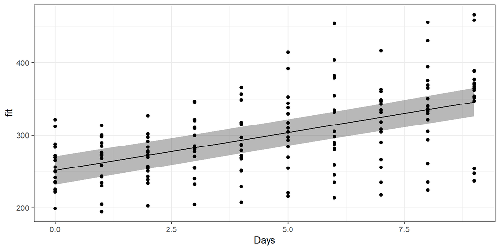

```r
ggplot(data = NewData, aes(x = Days, y = fit)) +
  geom_ribbon(alpha = 0.35, aes(ymin = lwr, ymax = upr)) +
  geom_line() + geom_point(data = sl, aes(x = Days, y = Reaction))
```

Зависимость времени реакции от продолжительности периода бессонницы без учета субъекта:

$$\widehat{Reaction}_{ij} = 251.4 + 10.5 Days_{ij}$$

## Предсказания фиксированной части модели с бутстрепом

```r
merBoot <- bootMer(M1,
                   function(x) predict(x, new_data = NewData, re.form = NA),
                   nsim = 1000)

b_se <- apply(merBoot$t, 2,
              function(x) quantile(x, probs = c(.025, .975),
                                   na.rm = TRUE))
NewData$lwr <- b_se[1, ]
NewData$upr <- b_se[2, ]

ggplot(data = NewData, aes(x = Days, y = fit)) +
  geom_ribbon(alpha = 0.35, aes(ymin = lwr, ymax = upr)) +
  geom_line() + geom_point(data = sl, aes(x = Days, y = Reaction))
```

[output not shown]

## Предсказания фиксированной части модели при помощи merTools

```r
NewData <-
  sl %>%
  group_by(Subject) %>%
  do(data.frame(Days = seq(min(.$Days), max(.$Days), length = 10)))

NewData$regFit <- predict(M1, newdata = NewData, type = "response")

library(merTools)
exampPreds <- predictInterval(M1,
                              newdata = NewData, stat = 'median',
                              type = "linear.prediction",
                              level = 0.95, n.sims = 1000)

# head(data.frame(NewData, exampPreds))
```

## Предсказания для уровней случайного фактора

```r
NewData$fit_subj <- predict(M1, NewData, type = 'response')
ggplot(NewData, aes(x = Days, y = fit_subj)) +
  geom_ribbon(alpha = 0.3, aes(ymin = lwr, ymax = upr)) +
  geom_line(aes(colour = Subject)) +
  geom_point(data = sl, aes(x = Days, y = Reaction, colour = Subject))  +
  guides(colour = guide_legend(ncol = 2))
```

[output not shown]

Зависимость времени реакции от продолжительности периода бессонницы для обследованных субъектов:

$$\widehat{Reaction}_{ij} = 251.4 + 10.5 Days_{ij} + b_{i}$$

## Важные замечания

Случайный фактор помогает учесть взаимозависимость наблюдений для каждого из субъектов – “индуцированные” корреляции.

После анализа остатков модели можно будет понять, стоит ли с ней работать дальше. Одна из потенциальных проблем – время реакции разных субъектов может меняться непараллельно. Возможно, модель придется переформулировать.

## Индуцированная корреляция

## Разберемся со случайной частью модели

$$\mathbf{Reaction} = \mathbf{X} \pmb{\beta} + \mathbf{Z} \mathbf{b} + \pmb{\varepsilon}$$

$\mathbf{b} \sim N(0, \mathbf{D})$ – случайные эффекты $b_i$ нормально распределены со средним 0 и матрицей ковариаций $\mathbf{D}$  
$\pmb{\varepsilon} \sim N(0, \pmb{\Sigma})$ – остатки модели нормально распределены со средним 0 и матрицей ковариаций $\pmb{\Sigma}$

Матрица ковариаций остатков:

$$\pmb{\Sigma} = \sigma^2 \cdot \begin{pmatrix} 1 & 0 & \cdots & 0 \\ 0 & 1 & \cdots & 0 \\ \vdots & \vdots & \ddots & \vdots \\ 0 & 0 & \cdots & 1 \end{pmatrix} = \begin{pmatrix} \sigma^2 & 0 & \cdots & 0 \\ 0 & \sigma^2 & \cdots & 0 \\ \vdots & \vdots & \ddots & \vdots \\ 0 & 0 & \cdots & \sigma^2 \end{pmatrix}$$

## Остатки модели должны быть независимы друг от друга

В матрице ковариаций остатков вне диагонали стоят нули, т.е. ковариация разных остатков равна нулю. Т.е. остатки независимы друг от друга.

$$\pmb{\Sigma} = \begin{pmatrix} \sigma^2 & 0 & \cdots & 0 \\ 0 & \sigma^2 & \cdots & 0 \\ \vdots & \vdots & \ddots & \vdots \\ 0 & 0 & \cdots & \sigma^2 \end{pmatrix}$$

В то же время, при появлении в модели случайного фактора отдельные значения переменной-отклика $\mathbf{Y}$ уже не будут независимы друг от друга.

## Матрица ковариаций переменной-отклика

$$\mathbf{Reaction} = \mathbf{X} \pmb{\beta} + \mathbf{Z} \mathbf{b} + \pmb{\varepsilon}$$
$$\mathbf{b} \sim N(0, \mathbf{D})$$

$$\pmb{\varepsilon} \sim N(0, \pmb{\Sigma})$$

При этом переменная-отклик $\mathbf{Y}$ нормально распределена со следующими параметрами:

$$\mathbf{Y} \sim N(\mathbf{X} \pmb{\beta}, \mathbf{V} )$$

Матрица ковариаций переменной-отклика:

$$\mathbf{V} = \mathbf{Z} \mathbf{D} \mathbf{Z'} + \pmb{\Sigma}$$

где $\mathbf{D}$ — матрица ковариаций случайных эффектов.

Т.е. **добавление случайных эффектов приводит к изменению ковариационной матрицы** $\mathbf{V}$

## Добавление случайных эффектов приводит к изменению ковариационной матрицы

$$\mathbf{V} = \mathbf{Z} \mathbf{D} \mathbf{Z'} + \pmb{\Sigma}$$

Для простейшей смешанной модели со случайным отрезком:

$$\mathbf{V} =
\begin{pmatrix} 1 \\ 1 \\ \vdots \\ 1 \end{pmatrix} \cdot \sigma_b^2 \cdot \begin{pmatrix} 1 & 1 & \cdots & 1 \end{pmatrix} +
\sigma^2 \cdot \begin{pmatrix} 1 & 0 & \cdots & 0 \\ 0 & 1 & \cdots & 0 \\ \vdots & \vdots & \ddots & \vdots \\ 0 & 0 & \cdots & 1 \end{pmatrix} = \\
= \begin{pmatrix} \sigma^2 + \sigma_b^2 & \sigma_b^2 & \cdots & \sigma_b^2 \\ \sigma_b^2 & \sigma^2 + \sigma_b^2 & \cdots & \sigma_b^2 \\ \vdots & \vdots & \ddots & \vdots \\ \sigma_b^2 & \sigma_b^2 & \sigma_b^2 & \sigma^2 + \sigma_b^2 \end{pmatrix}$$

## Индуцированная корреляция — следствие включения в модель случайных эффектов

$$\mathbf{V} = \begin{pmatrix} \sigma^2 + \sigma_b^2 & \sigma_b^2 & \cdots & \sigma_b^2 \\ \sigma_b^2 & \sigma^2 + \sigma_b^2 & \cdots & \sigma_b^2 \\ \vdots & \vdots & \ddots & \vdots \\ \sigma_b^2 & \sigma_b^2 & \sigma_b^2 & \sigma^2 + \sigma_b^2 \end{pmatrix}$$

- $\sigma_b^2$ — ковариация между наблюдениями одного субъекта.
- $\sigma^2 + \sigma_b^2$ — дисперсия.

Т.е. корреляция между наблюдениями одного субъекта $\sigma_b^2 / (\sigma^2 + \sigma_b^2)$

## Коэффициент внутриклассовой корреляции (intra-class correlation, ICC)

$$ICC = \sigma_b^2 / (\sigma^2 + \sigma_b^2)$$

Способ измерить, насколько коррелируют друг с другом наблюдения из одной и той же группы, заданной случайным фактором.

Если ICC низок, то наблюдения очень разные внутри групп, заданных уровнями случайного фактора.

Если ICC высок, то наблюдения очень похожи внутри каждой из групп, заданных случайным фактором.

ICC можно использовать как описательную статистику, но интереснее использовать его при планировании исследований.

Если в пилотном исследовании ICC маленький, то для надежной оценки эффекта этого случайного фактора нужно брать больше наблюдений в группе.

Если в пилотном исследовании ICC большой, то можно брать меньше наблюдений в группе.

## Вычислим коэффициент внутриклассовой корреляции

```r
summary(M1)
```

```
Linear mixed model fit by REML ['lmerMod']
Formula: Reaction ~ Days + (1 | Subject)
   Data: sl

REML criterion at convergence: 1786.5

Scaled residuals:
    Min      1Q  Median      3Q     Max
-3.2257 -0.5529  0.0109  0.5188  4.2506

Random effects:
 Groups   Name        Variance Std.Dev.
 Subject  (Intercept) 1378.2   37.12
 Residual              960.5   30.99
Number of obs: 180, groups:  Subject, 18

Fixed effects:
            Estimate Std. Error t value
(Intercept) 251.4051     9.7467   25.79
Days         10.4673     0.8042   13.02

Correlation of Fixed Effects:
     (Intr)
Days -0.371
```

```r
# Случайные эффекты отдельно
VarCorr(M1)
```

```
 Groups   Name        Std.Dev.
 Subject  (Intercept) 37.124
 Residual             30.991
```

```r
37.124^2 / (37.124^2 + 30.991^2)
```

```
[1] 0.5893148
```

## Диагностика модели

## Условия применимости

- Случайность и независимость наблюдений.
- Линейная связь.
- Нормальное распределение остатков.
- Гомогенность дисперсий остатков.
- Отсутствие коллинеарности предикторов.

## Данные для анализа остатков

```r
M1_diag <- data.frame(
  sl,
  .fitted = predict(M1),
  .resid = resid(M1, type = 'pearson'),
  .scresid = resid(M1, type = 'pearson', scaled = TRUE))

head(M1_diag, 4)
```

```
  Reaction Days Subject  .fitted     .resid    .scresid
1 249.5600    0     308 292.1888 -42.628815 -1.37551202
2 258.7047    1     308 302.6561 -43.951401 -1.41818815
3 250.8006    2     308 313.1234 -62.322787 -2.01098113
4 321.4398    3     308 323.5907  -2.150873 -0.06940261
```

- `.fitted` — предсказанные значения.
- `.resid` — Пирсоновские остатки.
- `.scresid` — стандартизованные Пирсоновские остатки.

## График остатков от предсказанных значений

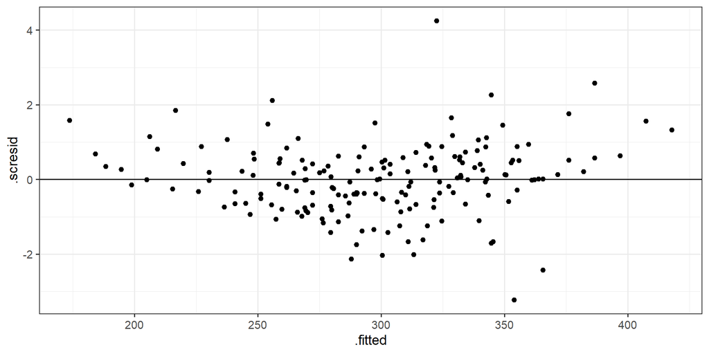

```r
gg_resid <- ggplot(M1_diag, aes(y = .scresid)) +
  geom_hline(yintercept = 0)
gg_resid + geom_point(aes(x = .fitted))
```

- Большие остатки.
- Гетерогенность дисперсий.

## Графики остатков от ковариат в модели и не в модели

```r
gg_resid + geom_boxplot(aes(x = factor(Days)))
```

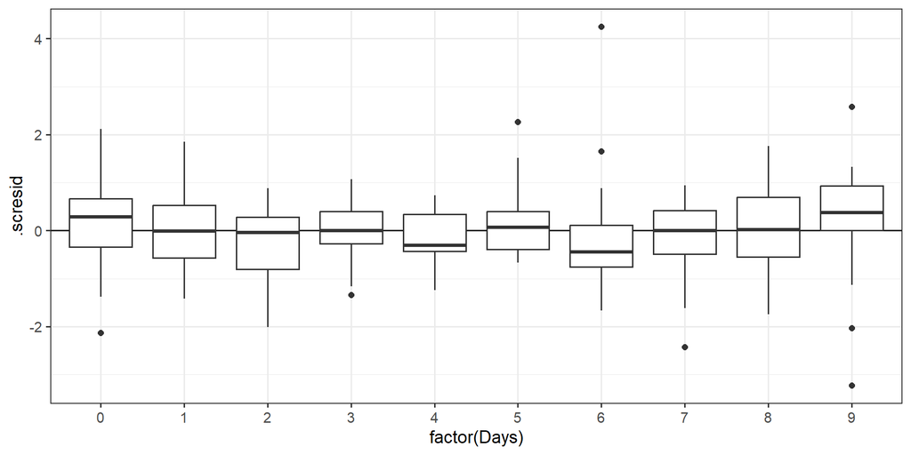

- Большие остатки в некоторые дни.
- Гетерогенность дисперсий.

## Графики остатков от ковариат в модели и не в модели

```r
gg_resid + geom_boxplot(aes(x = Subject))
```

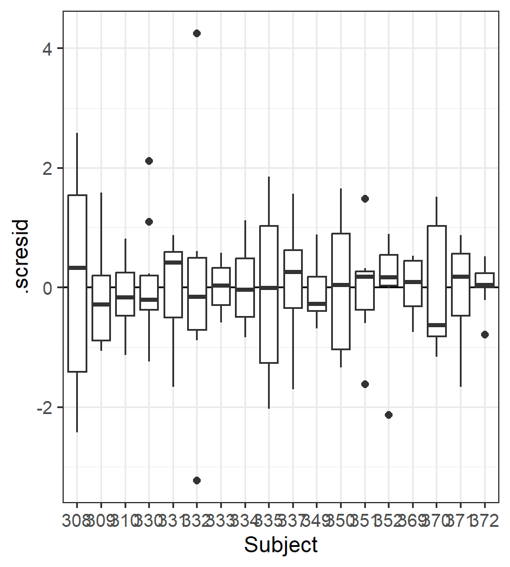

- Большие остатки у 332 субъекта.
- Гетерогенность дисперсий.

## GLMM со случайным отрезком и углом наклона

## GLMM со случайным отрезком и углом наклона

На графике индивидуальных эффектов было видно, что измерения для разных субъектов, возможно, идут непараллельно. Усложним модель — добавим случайные изменения угла наклона для каждого из субъектов.

Это можно биологически объяснить. Возможно, в зависимости от продолжительности бессонницы у разных субъектов скорость реакции будет ухудшаться разной скоростью: одни способны выдержать 9 дней почти без потерь, а другим уже пары дней может быть достаточно.

## Уравнение модели со случайным отрезком и углом наклона

$$Reaction_{ij} = \beta_0 + \beta_1 Days_{ij} + b_{i} + c_{ij} Days_{ij} + \varepsilon_{ij}$$

$b_{i} \sim N(0, \sigma_b)$ — случайный интерсепт для субъекта

$c_{ij} \sim N(0, \sigma_c)$ — случайный угол наклона для субъекта

$\varepsilon_{ij} \sim N(0, \sigma)$ — остатки модели

$i$ — субъекты, $j$ — дни

В матричном виде это записывается так:

$$\begin{pmatrix} Reaction _{1} \\ Reaction _{2} \\ \vdots \\ Reaction _{180} \end{pmatrix} =
\begin{pmatrix} 1 & Days _{1} \\ 1 & Days _{2} \\ \vdots \\ 1 & Days _{180} \end{pmatrix}
\begin{pmatrix} \beta _0 \\ \beta _1 \end{pmatrix} +
\begin{pmatrix} 1 & Days _{1} \\ 1 & Days _{2} \\ \vdots \\ 1 & Days _{180} \end{pmatrix}
\begin{pmatrix} b \\ c \end{pmatrix} +
\begin{pmatrix} \varepsilon _{1} \\ \varepsilon _{2}\\ \vdots \\ \varepsilon _{180} \end{pmatrix}$$

То есть: $\mathbf{Reaction} = \mathbf{X} \pmb{\beta} + \mathbf{Z} \mathbf{b} + \pmb{\varepsilon}$

В матрице $\mathbf{Z}$ появляется дополнительная колонка

## Подберем модель со случайным отрезком и углом наклона

Формат записи формулы для случайных эффектов в `lme4`

```r
(1 + угловой_коэффициент | отрезок)
```

```r
MS1 <- lmer(Reaction ~ Days + (1 + Days | Subject), data = sl)
```

## Уравнение модели со случайным отрезком и углом наклона

```r
summary(MS1)
```

```
Linear mixed model fit by REML ['lmerMod']
Formula: Reaction ~ Days + (1 + Days | Subject)
   Data: sl

REML criterion at convergence: 1743.6

Scaled residuals:
    Min      1Q  Median      3Q     Max
-3.9536 -0.4634  0.0231  0.4634  5.1793

Random effects:
 Groups   Name        Variance Std.Dev. Corr
 Subject  (Intercept) 612.10   24.741
          Days         35.07    5.922   0.07
 Residual             654.94   25.592
Number of obs: 180, groups:  Subject, 18

Fixed effects:
            Estimate Std. Error t value
(Intercept)  251.405      6.825  36.838
Days          10.467      1.546   6.771

Correlation of Fixed Effects:
     (Intr)
Days -0.138
```

$$Reaction_{ij} = 251.4 + 10.5 Days_{ij} + b_{i} + c_{ij} Days_{ij} + \varepsilon_{ij}$$

$b_{i} \sim N(0, 24.74)$ — случайный интерсепт для субъекта  
$c_{ij} \sim N(0, 5.92)$ — случайный угол наклона для субъекта  
$\varepsilon_{ij} \sim N(0, 25.59)$ — остатки модели  
$i$ — субъекты, $j$ — дни

## Данные для графика предсказаний фиксированной части модели

```r
library(dplyr)
NewData <- sl %>% group_by(Subject) %>%
  do(data.frame(Days = seq(min(.$Days), max(.$Days), length = 10)))

NewData$fit <- predict(MS1, NewData, type = 'response', re.form = NA)
head(NewData, 3)
```

```
# A tibble: 3 × 3
# Groups:   Subject [1]
  Subject  Days   fit
  <fct>   <dbl> <dbl>
1 308         0  251.
2 308         1  262.
3 308         2  272.
```

## Предсказания фиксированной части модели в матричном виде

Вычислим **приблизительные** доверительные интервалы.

```r
# Предсказанные значения при помощи матриц
X <- model.matrix(~ Days, data = NewData)
betas <- fixef(MS1)
NewData$fit <- X %*% betas

# Стандартные ошибки
NewData$SE <- sqrt( diag(X %*% vcov(MS1) %*% t(X)) )

NewData$lwr <- NewData$fit - 2 * NewData$SE
NewData$upr <- NewData$fit + 2 * NewData$SE
```

Более точные доверительные интервалы можно получить при помощи бутстрепа.

## График предсказаний фиксированной части модели

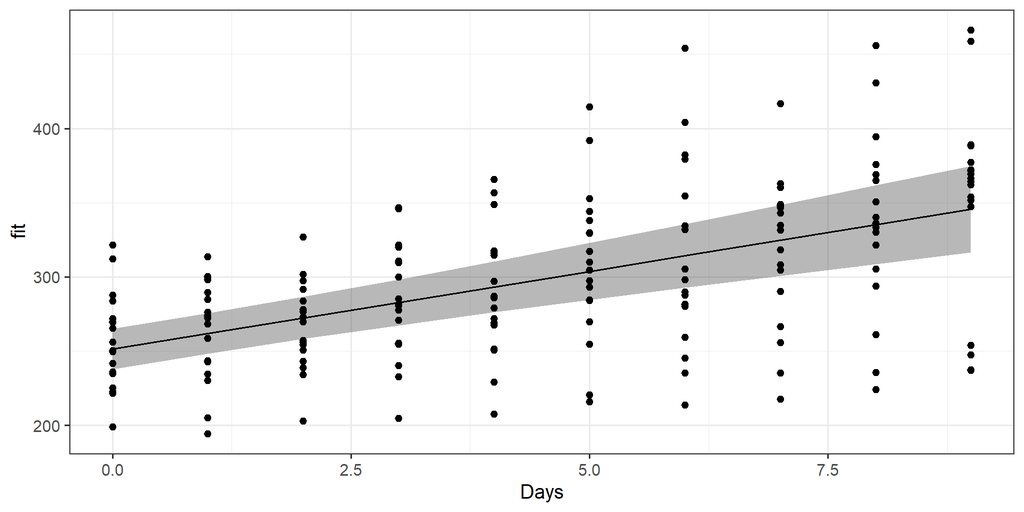

```r
ggplot(data = NewData, aes(x = Days, y = fit)) +
  geom_ribbon(alpha = 0.35, aes(ymin = lwr, ymax = upr)) +
  geom_line() + geom_point(data = sl, aes(x = Days, y = Reaction))
```

Зависимость времени реакции от продолжительности периода бессонницы без учета субъекта:

$$\widehat{Reaction}_{ij} = 251.4 + 10.5 Days_{ij}$$

## Предсказания для уровней случайного фактора

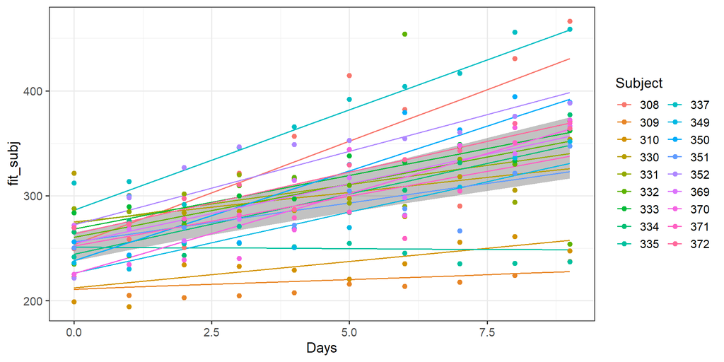

```r
NewData$fit_subj <- predict(MS1, NewData, type = 'response')
ggplot(NewData, aes(x = Days, y = fit_subj)) +
  geom_ribbon(alpha = 0.3, aes(ymin = lwr, ymax = upr)) +
  geom_line(aes(colour = Subject)) +
  geom_point(data = sl, aes(x = Days, y = Reaction, colour = Subject))  +
  guides(colour = guide_legend(ncol = 2))
```

Зависимость времени реакции от продолжительности периода бессонницы для обследованных субъектов:

$$\widehat{Reaction}_{ij} = 251.4 + 10.5 Days_{ij} + b_{i} + c_{ij} Days_{ij}$$

## Диагностика модели со случайным отрезком и углом наклона

## Данные для анализа остатков

```r
MS1_diag <- data.frame(
  sl,
  .fitted = predict(MS1),
  .resid = resid(MS1, type = 'pearson'),
  .scresid = resid(MS1, type = 'pearson', scaled = TRUE))

head(MS1_diag, 4)
```

```
  Reaction Days Subject  .fitted     .resid   .scresid
1 249.5600    0     308 253.6637  -4.103656 -0.1603504
2 258.7047    1     308 273.3299 -14.625218 -0.5714807
3 250.8006    2     308 292.9962 -42.195579 -1.6487932
4 321.4398    3     308 312.6624   8.777359  0.3429755
```

## График остатков от предсказанных значений

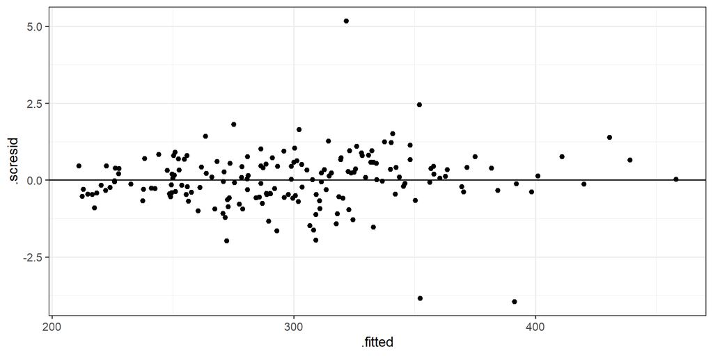

```r
gg_resid <- ggplot(MS1_diag, aes(y = .scresid)) +
  geom_hline(yintercept = 0)
gg_resid + geom_point(aes(x = .fitted))
```

- Несколько больших остатков.
- Гетерогенность дисперсий не выражена.

## Графики остатков от ковариат в модели и не в модели

```r
gg_resid + geom_boxplot(aes(x = factor(Days)))
```

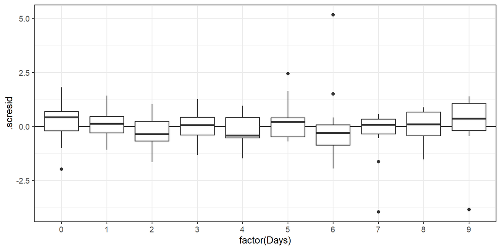

- Большие остатки в некоторые дни.
- Нет гетерогенности дисперсий остатков.

## Графики остатков от ковариат в модели и не в модели

```r
gg_resid + geom_boxplot(aes(x = Subject))
```

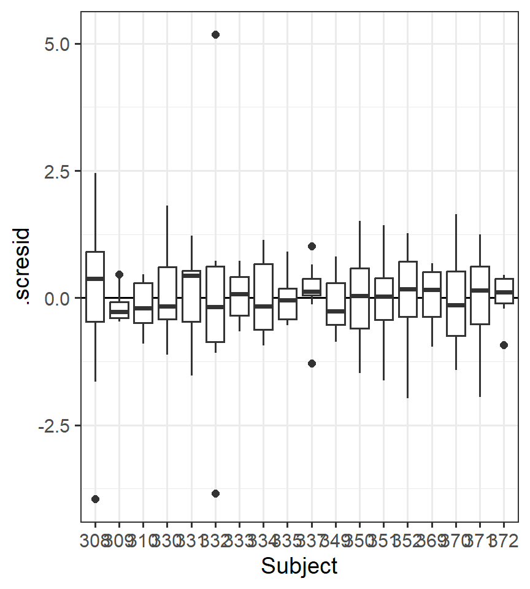

- Большие остатки у 332 субъекта.
- Гетерогенность дисперсий не выражена.

## Смешанные линейные модели

## Смешанные модели (Mixed Models)

Смешанными называются модели, включающие случайные факторы.

- Общие смешанные модели (General Linear Mixed Models) — только нормальное распределение зависимой переменной.
- Обобщенные смешанные модели (Generalized Linear Mixed Models) — распределения зависимой переменной могут быть другими (из семейства экспоненциальных распределений).

## Смешанная линейная модель в общем виде

$$\mathbf{Y} = \mathbf{X} \pmb{\beta} + \mathbf{Z} \mathbf{b} + \pmb{\varepsilon}$$

$\mathbf{b} \sim N(0, \mathbf{D})$ — случайные эффекты нормально распределены со средним 0 и матрицей ковариаций $\mathbf{D}$ (ее диагональные элементы – стандартное отклонение $\sigma_{b}$).

$\pmb{\varepsilon} \sim N(0, \pmb{\Sigma})$ — остатки модели нормально распределены со средним 0 и матрицей ковариаций $\pmb{\Sigma}$ (ее диагональные элементы – стандартное отклонение $\sigma$).

$\mathbf{X} \pmb{\beta}$ — фиксированная часть модели.

$\mathbf{Z} \mathbf{b} + \pmb{\varepsilon}$ — случайная часть модели.

В зависимости от устройства модельной матрицы для случайных эффектов $\mathbf{Z}$ смешанные модели делят на модели со случайным отрезком и модели со случайным отрезком и случайным углом наклона.

## Методы подбора параметров в смешанных моделях

Метод максимального правдоподобия (Maximum Likelihood, ML)

Метод ограниченного максимального правдоподобия (Restricted Maximum Likelihood, REML)

## Метод максимального правдоподобия, ML

Правдоподобие (likelihood) — измеряет соответствие реально наблюдаемых данных тем, что можно получить из модели при определенных значениях параметров.

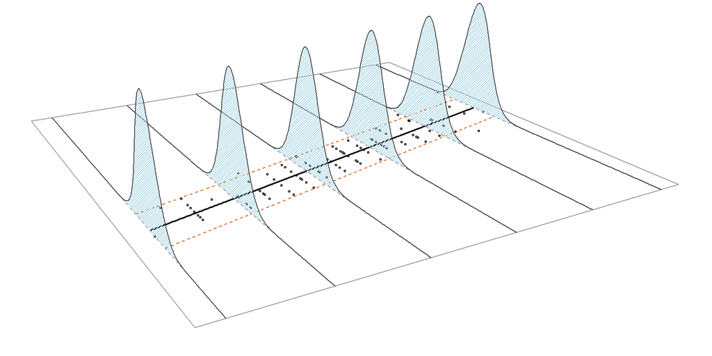

Это произведение вероятностей данных:

$$L(\theta| y_i) = \Pi^n _{i = 1}\color{purple}{f(y_i| \theta)}$$

Параметры модели должны максимизировать значение логарифма правдоподобия (loglikelihood):

$$\ln L(\theta| y_i) \longrightarrow \text{max}$$

Для тех, кому интересно разобраться вот [хорошая визуализация работы ML и тестов, основанных на LR](https://rpsychologist.com/likelihood/)

Magnusson, K. (2020). Understanding Maximum Likelihood: An interactive visualization (Version 0.1.2) [Web App]. R Psychologist. https://rpsychologist.com/likelihood/

## ML-оценки для дисперсий – смещенные

Например, ML оценка обычной выборочной дисперсии будет смещенной:

Хотелось бы:

$$\hat\sigma^2 = \cfrac{\sum(y_i - \hat y_i)^2}{n - p - 1}$$

На самом деле при ML:

$$\hat\sigma^2 = \cfrac{\sum(y_i - \hat y_i)^2}{n}$$

т.к. в знаменателе не $n - p - 1$, а $n$.

Аналогичные проблемы возникают при ML оценках для случайных эффектов в линейных моделях.

Это происходит потому, что в смешанной линейной модели

$$\mathbf{Y} = \mathbf{X} \pmb{\beta} + \mathbf{Z} \mathbf{b} + \pmb{\varepsilon}$$

$$\mathbf{Y} \sim N(\mathbf{X} \pmb{\beta}, \mathbf{V})$$
, где
$$\mathbf{V} = \mathbf{ZDZ'} + \pmb{\Sigma}$$

т.е. одновременно приходится оценивать $\pmb{\beta}$ и $\mathbf{V}$.

## Метод ограниченного максимального правдоподобия, REML

Ограниченное максимальное правдоподобие (Restricted maximum likelihood, REML) - это вариант метода ML, который используется для оценки параметров модели со *смешанными эффектами*. В отличие от ML, который оценивает фиксированные и случайные эффекты **одновременно**, REML оценивает только “дисперсионные” компоненты случайных эффектов, предполагая, что фиксированные эффекты известны. Удалив из модели фиксированные эффекты, REML может получить несмещенные оценки дисперсионных компонент случайных эффектов.

**Следствие 1**: *REML*, давая более точные оценки дисперсии, уменьшает вероятность ошибки I рода.

**Следствие 2**: *REML* следует использовать в тех анализах, где надо учесть неоднородности величин эффектов, вызванные случайными факторами, например в *метаанализе*.

## Метод ограниченного максимального правдоподобия, REML

$$\mathbf{Y} = \mathbf{X} \pmb{\beta} + \mathbf{Z} \mathbf{b} + \pmb{\varepsilon}$$

$${Y} \sim N(\mathbf{X} \pmb{\beta}, \mathbf{V})$$
где
$$\mathbf{V} = \mathbf{ZDZ'} + \pmb{\Sigma}$$

Если найти матрицу $\mathbf{A}$, ортогональную к $\mathbf{X'}$ (т.е. $\mathbf{A'X} = 0$), то умножив ее на $\mathbf{Y}$ можно избавиться от $\pmb{\beta}$:

$$\mathbf{A'Y} = \mathbf{A'X} \pmb{\beta} + \mathbf{A'V} = \mathbf{0} + \mathbf{A'V} = \mathbf{A'V}$$

$${A'Y} \sim N(\mathbf{0}, \mathbf{A'VA})$$

Тогда можно воспользоваться ML, чтобы найти $\mathbf{V}$.

В результате получатся несмещенные оценки дисперсий.

REML-оценки $\pmb{\beta}$ будут стремится к ML-оценкам при увеличении объема выборки.

## ML или REML?

Если нужны точные оценки фиксированных эффектов – ML.

Если нужны точные оценки случайных эффектов – REML.

ML больше подходит для простых моделей, а REML - для сложных моделей с большим количеством случайных эффектов.

ML больше подходит для больших объемов выборки, а REML - для малых и умеренных объемов.

Если нужно работать с правдоподобиями – следите, чтобы в моделях, подобранных REML была одинаковая фиксированная часть.

Для обобщенных (негауссовых) смешанных линейных моделей REML не определен – там используется ML.

## Тестирование гипотез в смешанных моделях

## Использование смешанных моделей для получения выводов

Тесты, которые традиционно применяются для GLM, дадут лишь **приблизительные результаты** для GLMM:

- t-(или z-) тесты Вальда для коэффициентов,
- тесты отношения правдоподобий (Likelihood ratio tests, LRT).

Поэтому для отбора моделей применяют подход, не связанный с тестами:

- информационные критерии (AIC, BIC и т.п.).

Наиболее точные результаты тестов можно получить, используя **“золотой стандарт”**:

- параметрический бутстреп.

## t-(или -z) тесты Вальда

$$H_0: \beta_k = 0, \qquad H_A: \beta_k \ne 0$$

$$\cfrac{b_k} {SE_{b_k}} \sim N(0, 1)\qquad$$
или
$$\qquad\cfrac{b_k} {SE_{b_k}} \sim t_{(df = n - p)}$$
, если нужно оценивать $\sigma$

$b_k$ — оценка коэффициента, $n$ — объем выборки, $p$ — число параметров модели.

t-(или -z) тесты Вальда дают лишь приблизительный результат, поэтому в пакете `lme4` даже не приводят уровни значимости в `summary()`. Не рекомендуется ими пользоваться.

```r
coef(summary(MS1))
```

```
             Estimate Std. Error   t value
(Intercept) 251.40510   6.824597 36.838090
Days         10.46729   1.545790  6.771481
```

## Тесты отношения правдоподобий (LRT)

$$LRT = 2\ln\left(\frac{L_{M_1}}{L_{M_2}}\right) = 2(\ln L_{M_1} - \ln L_{M_2})$$

- $M_1$ и $M_2$ — вложенные модели ($M_1$ — более полная, $M_2$ — уменьшенная),
- $L_{M_1}$, $L_{M_2}$ – правдоподобия моделей и $\ln L_{M_1}$, $\ln L_{M_2}$ – логарифмы правдоподобий.

Распределение LRT **аппроксимируют** распределением $\chi^2$ с $df = df_{M_2} - df_{M_1}$.

- LRT консервативен для случайных эффектов, т.к. тест гипотезы вида $H_0: \hat\sigma_k^2 = 0$ происходит на границе области возможных значений параметра.
- LRT либерален для фиксированных эффектов, дает заниженные уровни значимости.

## LRT для случайных эффектов

__Модели с одинаковой фиксированной частью, но разной случайной частью, будут вложенными, если они подобраны REML.

```r
MS1 <- lmer(Reaction ~ Days + (1 + Days | Subject), data = sl, REML = TRUE)
MS0 <- lmer(Reaction ~ Days + (1 | Subject), data = sl, REML = TRUE)
anova(MS1, MS0, refit = FALSE)
```

```
Data: sl
Models:
MS0: Reaction ~ Days + (1 | Subject)
MS1: Reaction ~ Days + (1 + Days | Subject)
    npar    AIC    BIC  logLik -2*log(L)  Chisq Df Pr(>Chisq)
MS0    4 1794.5 1807.2 -893.23    1786.5
MS1    6 1755.6 1774.8 -871.81    1743.6 42.837  2   4.99e-10 ***
---
Signif. codes:  0 '***' 0.001 '**' 0.01 '*' 0.05 '.' 0.1 ' ' 1
```

Время реакции у разных людей по-разному зависит от продолжительности бессонницы.

Обычно такие тесты не делают, набор случайных эффектов определяется устройством данных (дизайном эксперимента). Форма случайной части модели должна быть продумана до начала анализа.

## LRT для фиксированных эффектов

**Модели с одинаковой случайной частью, но разной фиксированной частью, будут вложенные, но только если они подобраны ML**.

```r
MS1.ml <- lmer(Reaction ~ Days + (1 + Days | Subject), data = sl, REML = FALSE)
MS0.ml <- lmer(Reaction ~ 1 + (1 + Days | Subject), data = sl, REML = FALSE)
anova(MS1.ml, MS0.ml)
```

```
Data: sl
Models:
MS0.ml: Reaction ~ 1 + (1 + Days | Subject)
MS1.ml: Reaction ~ Days + (1 + Days | Subject)
       npar    AIC    BIC  logLik -2*log(L)  Chisq Df Pr(>Chisq)
MS0.ml    5 1785.5 1801.4 -887.74    1775.5
MS1.ml    6 1763.9 1783.1 -875.97    1751.9 23.537  1  1.226e-06 ***
---
Signif. codes:  0 '***' 0.001 '**' 0.01 '*' 0.05 '.' 0.1 ' ' 1
```

Время реакции зависит от продолжительности бессонницы. Это будет вывод общий для всей популяции, из которой взята выборка.

## Сравнение моделей по AIC

**Это сравнение можно применять для моделей с одинаковой случайной частью, подобранные ML, как вложенные так и невложенные**.

```r
AIC(MS1.ml, MS0.ml)
```

```
       df      AIC
MS1.ml  6 1763.939
MS0.ml  5 1785.476
```

Время реакции зависит от продолжительности бессонницы (AIC).

## Бутстреп для тестирования значимости и для предсказаний

## Параметрический бутстреп для тестирования случайных эффектов

```r
# Значение LRT для сравниваемых моделей
my_LRT <- as.numeric(2 * (logLik(MS1) - logLik(MS0)))
# Бутстреп
boot_LRT <- numeric(500)
set.seed(42)
for (i in 1:500) {
  y <- unlist(simulate(MS0))
  m0 <- lmer(y ~ Days + (1 | Subject), sl, REML = TRUE)
  m1 <- lmer(y ~ Days + (1 + Days | Subject), sl, REML = TRUE)
  boot_LRT[i] <- as.numeric(2 * (logLik(m1) - logLik(m0)))
}
(p_val <- mean(boot_LRT > my_LRT))  # уровень значимости p
sqrt(p_val * (1 - p_val) / 500)  # SE для p
```

[output not shown]

## Бутстреп

Способ тестирования гипотез, при котором из данных многократно получают выборки (с повторениями).

Если по таким многократным выборкам построить распределение статистики, то оно будет стремиться к истинному распределению этой статистики.

Сгенерированное бутстрепом распределение статистики можно использовать для тестирования гипотез.

Бутстреп особенно удобен, когда невозможно получить распределение статистики аналитическим путем.

## Параметрический бутстреп для LRT

Чтобы при помощи бутстрепа получить оценку уровня значимости для LRT при сравнении двух моделей $M_{full}$ и $M_{reduced}$, нужно

1. Многократно повторить:
   - сгенерировать новые данные из уменьшенной модели,
   - по сгенерированным данным подобрать полную и уменьшенную модели и рассчитать LRT.
2. Построить распределение LRT по всем итерациям бутстрепа.

Уровень значимости – это доля итераций, в которых получено LRT больше, чем данное.

## Параметрический бутстреп для LRT фиксированных эффектов

В строке PBtest – значение LRT и его уровень значимости, полученный бутстрепом.

```r
library(pbkrtest)
pmod <- PBmodcomp(MS1.ml, MS0.ml, nsim = 100) # 1000 и больше для реальных данных
summary(pmod)
```

```
Bootstrap test; time: 3.42 sec; samples: 100; extremes: 0;
large : Reaction ~ Days + (1 + Days | Subject)
           stat     df     ddf   p.value
LRT      23.537  1.000         1.226e-06 ***
PBtest   23.537                 0.009901 **
Gamma    23.537                3.396e-07 ***
Bartlett 23.661  1.000         1.149e-06 ***
F        23.537  1.000 -377.06
---
Signif. codes:  0 '***' 0.001 '**' 0.01 '*' 0.05 '.' 0.1 ' ' 1
```

## Бутстреп-оценка доверительной зоны регрессии

Чтобы при помощи бутстрепа оценить положение зоны, где с 95% вероятностью будут лежать предсказанные значения, нужно:

1. Многократно повторить:
   - сгенерировать новые данные из модели
   - по сгенерированным данным подобрать модель и получить ее предсказания
2. Построить распределение предсказанных значений по всем итерациям бутстрепа.

95% доверительная зона регрессии — это область, куда попали предсказанные значения в 95% итераций (т.е. между 0.025 и 0.975 персентилями).

## Бутстреп-оценка доверительной зоны регрессии

```r
NewData <- sl %>% group_by(Subject) %>%
  do(data.frame(Days = seq(min(.$Days), max(.$Days), length = 10)))
NewData$fit <- predict(MS1, NewData, type = 'response', re.form = NA)

# Многократно симулируем данные из модели и получаем для них предсказанные значения
bMS1 <- bootMer(x = MS1,
                FUN = function(x) predict(x, new_data = NewData, re.form = NA),
                nsim = 100)

# Рассчитываем квантили предсказанных значений для всех итераций бутстрепа
b_se <- apply(X = bMS1$t,
              MARGIN = 2,
              FUN = function(x) quantile(x, probs = c(0.025, 0.975), na.rm = TRUE))

# Доверительная зона для предсказанных значений
NewData$lwr <- b_se[1, ]
NewData$upr <- b_se[2, ]
```

## График предсказаний фиксированной части модели

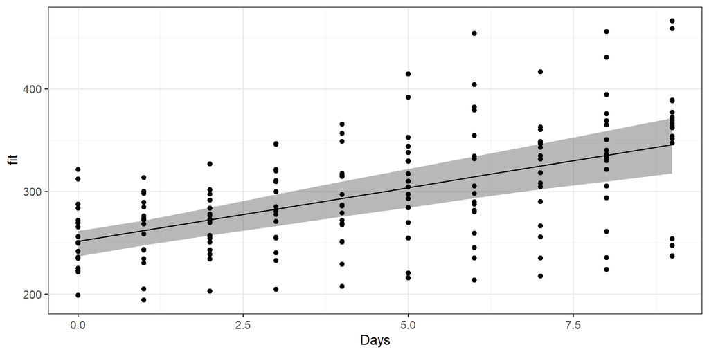

```r
ggplot(data = NewData, aes(x = Days, y = fit)) +
  geom_ribbon(alpha = 0.35, aes(ymin = lwr, ymax = upr)) +
  geom_line() + geom_point(data = sl, aes(x = Days, y = Reaction))
```

## Take-home messages

| Свойства | Фиксированные факторы | Случайные факторы |
| --- | --- | --- |
| Уровни фактора | фиксированные, заранее определенные и потенциально воспроизводимые уровни | случайная выборка из всех возможных уровней |
| Используются для тестирования гипотез | о средних значениях отклика между уровнями фактора $H_{0}: \mu _1 = \mu _2 = \ldots = \mu _i = \mu$ | о дисперсии отклика между уровнями фактора $H_{0}: \sigma_{rand.fact.}^2 = 0$ |
| Выводы можно экстраполировать | только на уровни из анализа | на все возможные уровни |
| Число уровней фактора | Осторожно! Если уровней фактора слишком много, то нужно подбирать слишком много коэффициентов — должно быть много данных | Важно! Для точной оценки $\sigma$ нужно много уровней фактора — не менее 5 |

## Take-home messages

- Смешанные модели могут включать случайные и фиксированные факторы.
  - Градации фиксированных факторов заранее определены, а выводы можно экстраполировать только на такие уровни, которые были задействованы в анализе. Тестируется гипотеза о равенстве средних в группах.
  - Градации случайных факторов — выборка из возможных уровней, а выводы можно экстраполировать на другие уровни. Тестируется гипотеза о дисперсии между группами.
- Есть два способа подбора коэффициентов в смешанных моделях: ML и REML. Для разных этапов анализа важно, каким именно способом подобрана модель.
- Коэффициент внутриклассовой корреляции оценивает, насколько коррелируют друг с другом наблюдения из одной и той же группы случайного фактора.
- Случайные факторы могут описывать вариацию как интерсептов, так и коэффициентов угла наклона.
- Модели со смешанными эффектами позволяют получить предсказания как общем уровне, так и на уровне отдельных субъектов.

## Дополнительные ресурсы

- Crawley, M.J. (2007). The R Book (Wiley).
- **Faraway, J. J. (2017). Extending the linear model with R: generalized linear, mixed effects and nonparametric regression models (Vol. 124). CRC press.**
- Zuur, A. F., Hilbe, J., & Ieno, E. N. (2013). A Beginner’s Guide to GLM and GLMM with R: A Frequentist and Bayesian Perspective for Ecologists. Highland Statistics.
- **Zuur, A.F., Ieno, E.N., Walker, N., Saveliev, A.A., and Smith, G.M. (2009). Mixed Effects Models and Extensions in Ecology With R (Springer)**
- Pinheiro, J., Bates, D. (2000). Mixed-Effects Models in S and S-PLUS. Springer